# Análisis Multivariado

William Gomez

2024-08-15

## Tarea 1

**1.** El archivo ‘anexo1.csv’ contiene los datos de una muestra de vectores aleatorios de 3 componentes.
$$X_1, X_2, \ldots, X_n$$

**a.** Evalue la normalidad multivariada de la muestra dada.  
**b.** Si el vector de medias poblacionales es $\mu = \begin{bmatrix} 0.1 & -0.2 & 0.05 \end{bmatrix}^T$ y $S$ es la matriz de varianzas-covarianzas muestrales. ¿Cuál es la distribución aproximada de

$$40 \left( \bar{X} - \begin{bmatrix} 0.1 & -0.2 & 0.05
\end{bmatrix}^T \right) S^{-1} \left( \bar{X} - \begin{bmatrix} 0.1
& -0.2 & 0.05 \end{bmatrix}^T \right) ?$$

**c.** Usando la **distancia cuadrada generalizada** establezca si existen valores atípicos.

#### Solución 1

```r
X1 <- read.csv2("anexo1.csv")
n <- nrow(X1)
n
```

```
## [1] 40
```

```r
p <- ncol(X1)
p
```

```
## [1] 3
```

```r
head(X1)
```

```
##           X1         X2         X3
## 1 -2.3932177 -2.1584719 -1.5865685
## 2  2.7740539  2.8226023  3.2069833
## 3  0.5384641  0.1086596 -0.4906402
## 4  2.0426030  1.8232092  1.3567716
## 5  1.7732396  2.2194384  1.7299784
## 6 -0.9932595 -0.9960262 -0.8165494
```

1. Para evaluar la normalidad multivariada de la muestra, usaremos el test de Mardia.

```r
#Cargar la Librería para el Test de Mardia
library(MVN)
```

```r
mardia_test <- mvn(X1, mvnTest = "mardia")
mardia_test
```

```
## $multivariateNormality
##              Test          Statistic           p value Result
## 1 Mardia Skewness   3.44263279082527 0.969010425206423    YES
## 2 Mardia Kurtosis -0.959974119510589 0.337068240452895    YES
## 3             MVN               <NA>              <NA>    YES
##
## $univariateNormality
##               Test  Variable Statistic   p value Normality
## 1 Anderson-Darling    X1        0.1901    0.8931    YES
## 2 Anderson-Darling    X2        0.1688    0.9296    YES
## 3 Anderson-Darling    X3        0.3570    0.4388    YES
##
## $Descriptives
##     n         Mean  Std.Dev      Median       Min      Max       25th     75th
## X1 40  0.013463668 1.816194 -0.06227406 -3.952481 3.673581 -1.2041901 1.196851
## X2 40 -0.001685572 1.768519 -0.02411968 -3.656188 3.713670 -1.0884103 1.043540
## X3 40 -0.082345327 1.659509 -0.45863078 -3.778099 3.206983 -0.9503632 1.102676
##           Skew   Kurtosis
## X1 -0.02735881 -0.5332226
## X2  0.02255044 -0.4845468
## X3 -0.14809282 -0.3814142
```

Podemos observar que el test de normalidad multivariada nos arroja resultados afirmativos tanto en el ‘Mardia Skewness’ como en el ‘Mardia Kurtosis’, lo que sugiere que existe normalidad multivariada en la muestra. Es decir, las variables consideradas en la muestra se distribuyen de manera normal multivariada por el test de Mardia.

La estadística de prueba
$$n (X - \mu)^\top S^{-1} (X - \mu) \approx \chi^2_p$$
con $\mu = \begin{bmatrix} 0.1 & -0.2 & 0.05 \end{bmatrix}^T$, $S$ y $n=40$, tiene una distribución
$$\chi^2_p$$
Esto significa que la estadística de prueba sigue una distribución chi-cuadrada con p grados de libertad.

```r
Xbarra<-colMeans(X1)
S<-cov(X1)
S_inv<-solve(S)
mu <- c(0.1, -0.2, 0.05)
result <- 40 * t(Xbarra - mu) %*% S_inv %*% (Xbarra - mu)
result
```

```
##         [,1]
## [1,] 73.3465
```

```r
alpha <- 0.05
df <- 3  # grados de libertad
chi_square_critical <- qchisq(1 - alpha, df)
chi_square_critical
```

```
## [1] 7.814728
```

La estadística de prueba calculada (73.3465) es mucho mayor que el valor crítico (7.814728) para alfa=0.05 y 3 grados de libertad. Por tanto, se rechaza la hipótesis nula y se indica que hay una diferencia significativa entre la media muestral y el vector de medias poblacionales especificado.

```r
# Calcular la distancia cuadrada generalizada para cada observación
distances <- apply(X1, 1, function(x) {
  (x - Xbarra) %*% S_inv %*% (x - Xbarra)
})

distances
```

```
##  [1] 2.536907504 4.811323299 2.644067334 1.522594023 5.308019728 0.412991046
##  [7] 3.363817514 1.457424912 5.522028495 2.526179095 5.649669018 2.929268078
## [13] 6.040574759 4.189424293 3.843993707 1.764055796 5.306311722 1.500701698
## [19] 4.500066237 1.184538732 6.252197434 4.782488434 0.003357339 0.691094899
## [25] 2.570044223 1.173329974 0.098347107 0.147513309 6.855704467 2.768477762
## [31] 0.325131091 1.172094524 0.538101578 1.886409407 6.815650410 3.077184194
## [37] 3.160333807 5.005251987 1.606795282 1.056535781
```

```r
alpha <- 0.05  # Nivel de significancia
df <- ncol(X1) - 1  # Grados de libertad (número de p - 1)
quantile_chi2 <- qchisq(1 - alpha, df)
quantile_chi2
```

```
## [1] 5.991465
```

```r
# Paso 3: Comparar distancias con el cuantíl
outliers <- distances[distances > quantile_chi2]  # Valores atípicos
outlier_indices <- which(distances > quantile_chi2)  # Índices de los valores atípicos
outlier_indices
```

```
## [1] 13 21 29 35
```

Podemos también utilizar un método gráfico.

```r
Out<-mvn(X1, mvnTest = "mardia",
multivariateOutlierMethod ="adj")
```

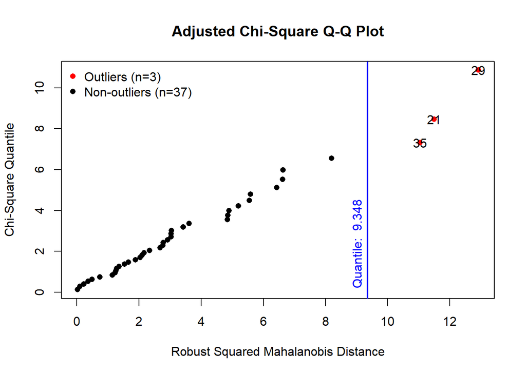

**2.** Los datos Protein del paquete MultBiplotR contiene información sobre datos nutricionales de 9 diferentes fuentes de proteínas para los habitantes de 25 países europeos alrededor de 1970:

### Consumo de Proteínas por Fuente

- **RedMeat**: Consumo de proteínas provenientes de carnes rojas.
- **WhiteMeat**: Consumo de proteínas provenientes de carnes blancas.
- **Eggs**: Consumo de proteínas del huevo.
- **Milk**: Consumo de proteínas de la leche.
- **Fish**: Consumo de proteínas provenientes del pescado.
- **Cereals**: Consumo de proteínas procedentes de cereales.
- **Starch**: Consumo de proteínas provenientes de carbohidratos.
- **Nuts**: Consumo de proteínas procedentes de cereales, frutos secos y semillas oleaginosas.
- **FruitVeg**: Consumo de proteínas procedentes de frutas y verduras.

Estos datos fueron colectados inicialmente para entender las diferencias nutricionales entre los países europeos.

1. Determine y analice el vector de medias y la matriz de covarianzas muestrales para las diferentes regiones.
2. Calcule la media de las variables por regiones. ¿Qué puede decir al respecto?
3. Intente construir grupos de países usando representaciones pictóricas (gráficos de estrellas o caras de Chernoff).
4. Utilice las herramientas de gráficas más adecuadas para verificar normalidad multivariada.
5. Realice la prueba de Mardia para verificar las hipótesis:
   - $H_0$: Los datos provienen de una población Normal Multivariada.
   - $H_1$: Los datos NO provienen de una población Normal Multivariada.
6. Verifique si hay outliers (multivariados) e identifíquelos.
7. Pruebe las hipótesis:
   - $H_0: \mu = \mu_0$
   - $H_1: \mu \neq \mu_0$

   donde $\mu_0 = \begin{bmatrix} 9 & 7 & 2 & 15 & 5 & 30 & 4 & 3 & 4 \end{bmatrix}^T$.
   1. De forma univariada.
   2. De forma multivariada.

Comente los resultados.

```r
library(MultBiplotR)
```

```r
data("Protein")

region_Sur <- subset(Protein, Region == "South")
region_centro <- subset(Protein, Region == "Center")
region_norte <- subset(Protein, Region == "North")
```

1. En el dataset existen 3 regiones.

#### Region Sur:

```r
summary(region_Sur)
```

```
##  Comunist    Region     Red_Meat        White_Meat         Eggs
##  No :4    North :0   Min.   : 4.400   Min.   :1.400   Min.   :0.500
##  Yes:4    Center:0   1st Qu.: 6.200   1st Qu.:3.300   1st Qu.:1.175
##           South :8   Median : 7.450   Median :4.350   Median :1.550
##                      Mean   : 7.625   Mean   :4.237   Mean   :1.837
##                      3rd Qu.: 9.275   3rd Qu.:5.325   3rd Qu.:2.825
##                      Max.   :10.200   Max.   :6.300   Max.   :3.100
##       Milk             Fish            Cereal          Starch
##  Min.   : 4.900   Min.   : 0.200   Min.   :27.00   Min.   :0.600
##  1st Qu.: 8.525   1st Qu.: 0.900   1st Qu.:34.90   1st Qu.:1.850
##  Median : 9.200   Median : 2.300   Median :42.00   Median :2.600
##  Mean   :10.325   Mean   : 4.188   Mean   :42.40   Mean   :2.962
##  3rd Qu.:11.750   3rd Qu.: 6.175   3rd Qu.:51.17   3rd Qu.:3.750
##  Max.   :17.600   Max.   :14.200   Max.   :56.70   Max.   :5.900
##       Nuts       Fruits_Vegetables
##  Min.   :3.700   Min.   :1.700
##  1st Qu.:4.600   1st Qu.:3.100
##  Median :5.400   Median :5.350
##  Mean   :5.362   Mean   :5.025
##  3rd Qu.:5.750   3rd Qu.:6.825
##  Max.   :7.800   Max.   :7.900
```

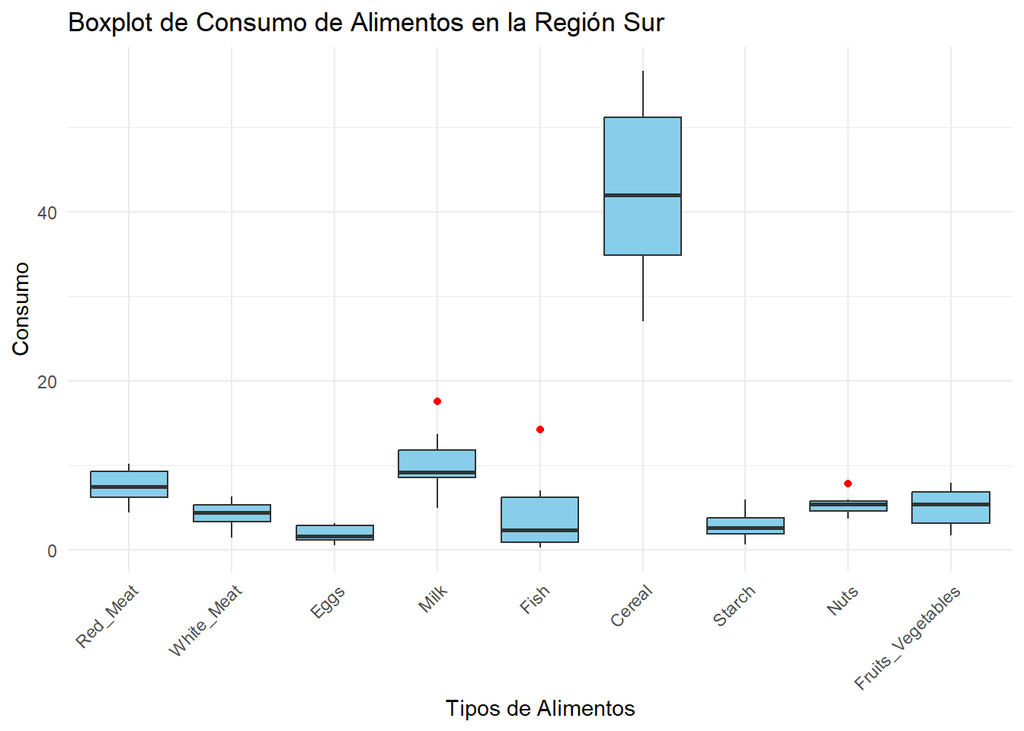

La región Sur se caracteriza por un elevado consumo de cereal por encima que cualquier otra cosa. El consumo de leche tiende a ser también algo común en esta región.

#### Region Centro:

```r
summary(region_centro)
```

```
##  Comunist    Region      Red_Meat       White_Meat         Eggs
##  No :8    North : 0   Min.   : 5.30   Min.   : 4.60   Min.   :2.100
##  Yes:5    Center:13   1st Qu.: 8.90   1st Qu.: 9.90   1st Qu.:2.900
##           South : 0   Median : 9.70   Median :10.20   Median :3.600
##                       Mean   :11.18   Mean   :10.41   Mean   :3.546
##                       3rd Qu.:13.50   3rd Qu.:12.40   3rd Qu.:4.100
##                       Max.   :18.00   Max.   :14.00   Max.   :4.700
##       Milk            Fish           Cereal          Starch         Nuts
##  Min.   : 9.70   Min.   :0.300   Min.   :18.60   Min.   :2.8   Min.   :0.800
##  1st Qu.:16.60   1st Qu.:2.200   1st Qu.:24.30   1st Qu.:4.2   1st Qu.:1.500
##  Median :19.30   Median :3.000   Median :26.60   Median :5.0   Median :2.000
##  Mean   :18.35   Mean   :3.131   Mean   :28.95   Mean   :5.0   Mean   :2.246
##  3rd Qu.:20.60   3rd Qu.:4.300   3rd Qu.:34.30   3rd Qu.:5.9   3rd Qu.:2.400
##  Max.   :25.80   Max.   :5.700   Max.   :43.60   Max.   :6.5   Max.   :5.400
##  Fruits_Vegetables
##  Min.   :2.900
##  1st Qu.:3.600
##  Median :4.000
##  Mean   :4.208
##  3rd Qu.:4.300
##  Max.   :6.600
```

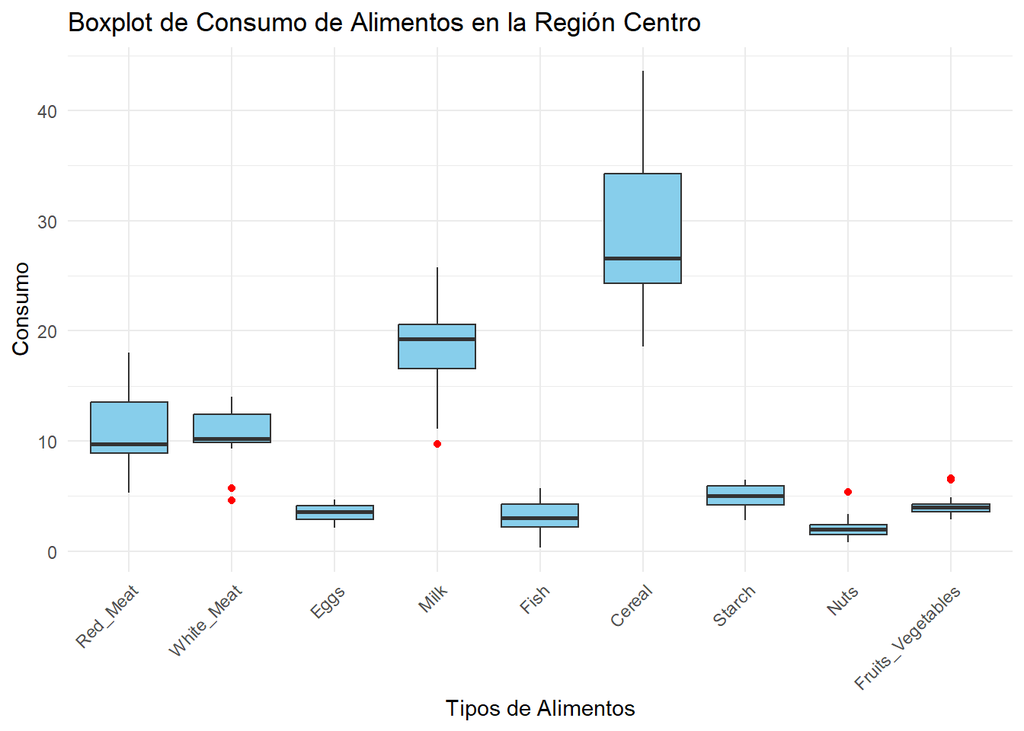

La región Centro se caracteriza también por un consumo elevado de Cereal, pero en menor cantidad. Sin embargo, su población muestra una preferencia mayor a la leche que ne la región Sur. Las carnes rojas y blancas son igualmente una parte importante en la dieta de esta región.

#### Region Norte:

```r
summary(region_norte)
```

```
##  Comunist    Region     Red_Meat        White_Meat         Eggs
##  No :4    North :4   Min.   : 9.400   Min.   : 4.70   Min.   :2.70
##  Yes:0    Center:0   1st Qu.: 9.475   1st Qu.: 4.85   1st Qu.:2.70
##           South :0   Median : 9.700   Median : 6.35   Median :3.10
##                      Mean   : 9.850   Mean   : 7.05   Mean   :3.15
##                      3rd Qu.:10.075   3rd Qu.: 8.55   3rd Qu.:3.55
##                      Max.   :10.600   Max.   :10.80   Max.   :3.70
##       Milk            Fish           Cereal          Starch
##  Min.   :23.30   Min.   :5.800   Min.   :19.50   Min.   :3.700
##  1st Qu.:24.35   1st Qu.:7.075   1st Qu.:21.30   1st Qu.:4.375
##  Median :24.85   Median :8.600   Median :22.45   Median :4.700
##  Mean   :26.68   Mean   :8.225   Mean   :22.68   Mean   :4.550
##  3rd Qu.:27.18   3rd Qu.:9.750   3rd Qu.:23.82   3rd Qu.:4.875
##  Max.   :33.70   Max.   :9.900   Max.   :26.30   Max.   :5.100
##       Nuts       Fruits_Vegetables
##  Min.   :0.700   Min.   :1.400
##  1st Qu.:0.925   1st Qu.:1.850
##  Median :1.200   Median :2.200
##  Mean   :1.175   Mean   :2.125
##  3rd Qu.:1.450   3rd Qu.:2.475
##  Max.   :1.600   Max.   :2.700
```

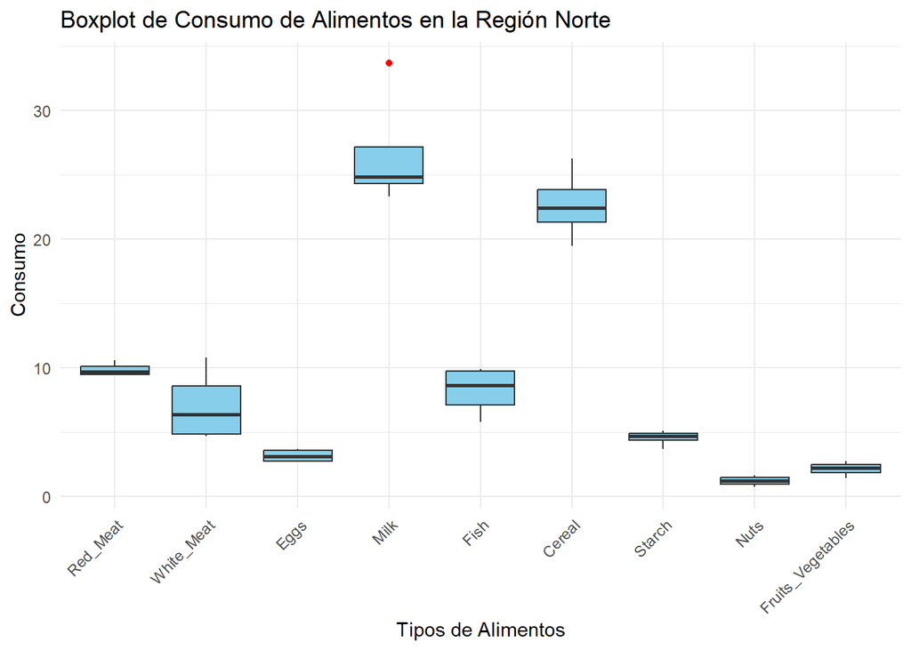

La región Norte se caracteriza por el consumo elevado de leche seguido a su vez por un gran consumo de cereal. Entre los alimentos con importancia en su población estan las carnes rojas, blancas y el pescado.

```r
matriz_covarianza_por_region <- lapply(split(Protein[, -c(1, 2)], Protein$Region), cov)
matriz_covarianza_por_region
```

```
## $North
##                      Red_Meat White_Meat        Eggs       Milk        Fish
## Red_Meat           0.29666667  1.5533333  0.26333333 -0.7650000  0.46833333
## White_Meat         1.55333333  8.2566667  1.45000000 -4.9783333  2.49500000
## Eggs               0.26333333  1.4500000  0.27666667 -1.0850000  0.36500000
## Milk              -0.76500000 -4.9783333 -1.08500000 22.4825000 -7.79583333
## Fish               0.46833333  2.4950000  0.36500000 -7.7958333  3.79583333
## Cereal            -0.71833333 -4.6150000 -1.10500000 10.6458333 -2.43583333
## Starch            -0.02333333 -0.3333333 -0.14333333  1.6516667 -0.07500000
## Nuts              -0.15833333 -0.7450000 -0.09833333 -0.7708333  0.03083333
## Fruits_Vegetables  0.06500000  0.3816667  0.05833333 -2.4158333  1.05250000
##                       Cereal      Starch        Nuts Fruits_Vegetables
## Red_Meat          -0.7183333 -0.02333333 -0.15833333        0.06500000
## White_Meat        -4.6150000 -0.33333333 -0.74500000        0.38166667
## Eggs              -1.1050000 -0.14333333 -0.09833333        0.05833333
## Milk              10.6458333  1.65166667 -0.77083333       -2.41583333
## Fish              -2.4358333 -0.07500000  0.03083333        1.05250000
## Cereal             7.9758333  1.50500000 -0.28083333       -0.75250000
## Starch             1.5050000  0.36333333 -0.12833333       -0.06500000
## Nuts              -0.2808333 -0.12833333  0.16250000        0.07083333
## Fruits_Vegetables -0.7525000 -0.06500000  0.07083333        0.31583333
##
## $Center
##                      Red_Meat White_Meat        Eggs        Milk       Fish
## Red_Meat           14.6735897 -4.5664744  1.51615385   9.7978205  3.3441026
## White_Meat         -4.5664744  7.6274359  0.37628205  -1.1695513 -1.3427564
## Eggs                1.5161538  0.3762821  0.65935897   1.6885256  0.2859615
## Milk                9.7978205 -1.1695513  1.68852564  23.8326923  0.2542949
## Fish                3.3441026 -1.3427564  0.28596154   0.2542949  2.2839744
## Cereal            -14.0588462 -6.8528846 -4.71480769 -18.2364744 -4.2882051
## Starch             -0.2300000 -1.2300000 -0.03666667  -1.2075000  0.7283333
## Nuts               -0.3980128 -1.2287179 -0.30147436  -1.4564744 -0.6632051
## Fruits_Vegetables   0.1743590  0.6391026 -0.31621795   0.2037821  0.3364103
##                       Cereal      Starch        Nuts Fruits_Vegetables
## Red_Meat          -14.058846 -0.23000000 -0.39801282        0.17435897
## White_Meat         -6.852885 -1.23000000 -1.22871795        0.63910256
## Eggs               -4.714808 -0.03666667 -0.30147436       -0.31621795
## Milk              -18.236474 -1.20750000 -1.45647436        0.20378205
## Fish               -4.288205  0.72833333 -0.66320513        0.33641026
## Cereal             54.344359  1.26000000  4.96185897        1.14711538
```

[output cut: 10 more lines]

```
## Fish              -0.9567857 -1.97089286  0.9119643 -5.30678571  22.7955357
## Cereal            -4.5957143  9.42857143 -3.7471429  6.85000000 -43.1157143
## Starch            -2.1803571  0.00875000  0.4530357 -3.12892857   7.2708929
## Nuts               0.6467857 -1.03125000  0.3430357  2.80821429   0.4708929
## Fruits_Vegetables  0.2207143 -0.24964286  1.4832143  0.46071429   9.3532143
##                       Cereal      Starch       Nuts Fruits_Vegetables
## Red_Meat           -4.595714  -2.1803571  0.6467857         0.2207143
## White_Meat          9.428571   0.0087500 -1.0312500        -0.2496429
## Eggs               -3.747143   0.4530357  0.3430357         1.4832143
## Milk                6.850000  -3.1289286  2.8082143         0.4607143
## Fish              -43.115714   7.2708929  0.4708929         9.3532143
## Cereal            125.977143 -14.4157143 -1.7614286       -19.3600000
## Starch            -14.415714   3.7883929  0.1941071         2.9782143
## Nuts               -1.761429   0.1941071  1.5283929         0.2167857
## Fruits_Vegetables -19.360000   2.9782143  0.2167857         5.4278571
```

Por otro lado, la matriz de covarianzas muestra alta varianza en ‘Milk’ (22.4825), lo que indica un consumo muy variable. Existe una covarianza positiva entre ‘Red_Meat’ y ‘White_Meat’ (1.5533), sugiriendo que a medida que aumenta el consumo de carne roja, también lo hace el de carne blanca. Sin embargo, la covarianza negativa entre ‘Milk’ y ‘Fish’ (-7.7958) indica que los hogares que consumen más leche tienden a consumir menos pescado.

En la region Centro se observa una alta varianza en ‘Milk’ (23.8327) y una covarianza negativa entre ‘Red_Meat’ y ‘White_Meat’ (-4.5665), sugiriendo que un aumento en el consumo de carne roja está asociado con una disminución en el de carne blanca. Además, la covarianza negativa en Cereal con otras variables sugiere relaciones inversas en el consumo, lo que podría reflejar preferencias alimentarias distintivas.

En la región Sur la varianza en ‘Fish’ (22.7955) es notablemente alta, lo que indica un consumo muy variable. La covarianza negativa entre ‘Cereal’ y ‘Fish’ (-43.1157) sugiere que los hogares que consumen más pescado tienden a consumir menos cereal, mientras que la covarianza positiva entre ‘Milk’ y ‘Eggs’ (2.1518) sugiere que ambos productos son consumidos conjuntamente en esta región.

```r
media_por_region <- aggregate(. ~ Region, data = Protein, FUN = mean)
media_por_region <- media_por_region[, -c(1, 2)]
media_por_region
```

```
##   Red_Meat White_Meat     Eggs     Milk     Fish   Cereal Starch     Nuts
## 1  9.85000    7.05000 3.150000 26.67500 8.225000 22.67500 4.5500 1.175000
## 2 11.17692   10.40769 3.546154 18.34615 3.130769 28.94615 5.0000 2.246154
## 3  7.62500    4.23750 1.837500 10.32500 4.187500 42.40000 2.9625 5.362500
##   Fruits_Vegetables
## 1          2.125000
## 2          4.207692
## 3          5.025000
```

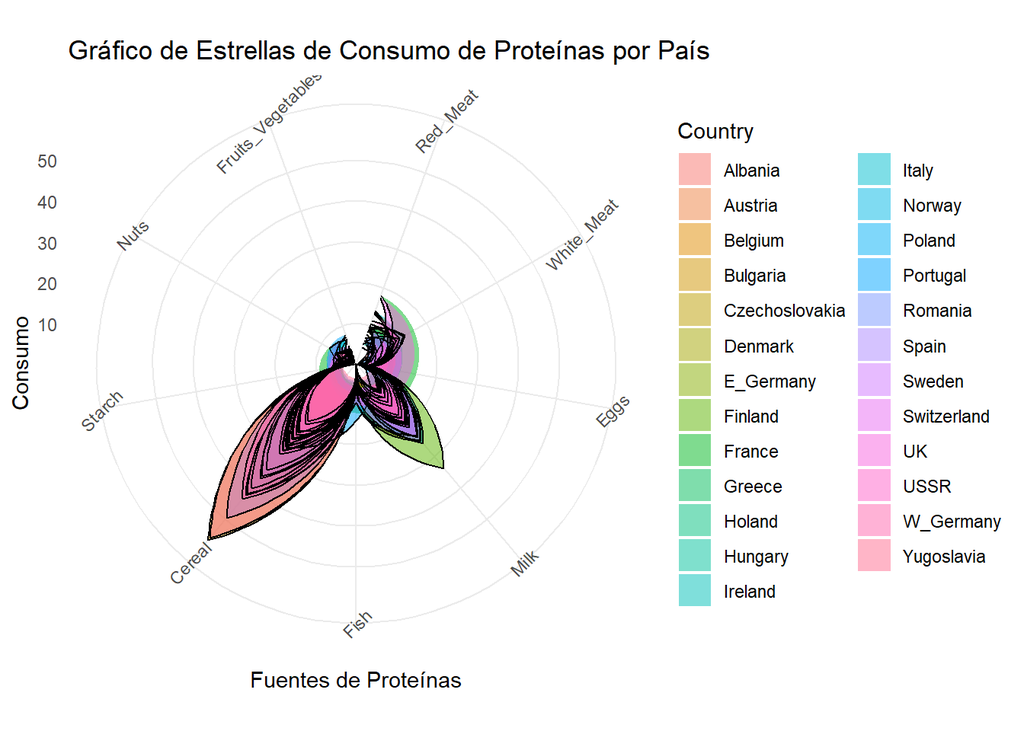

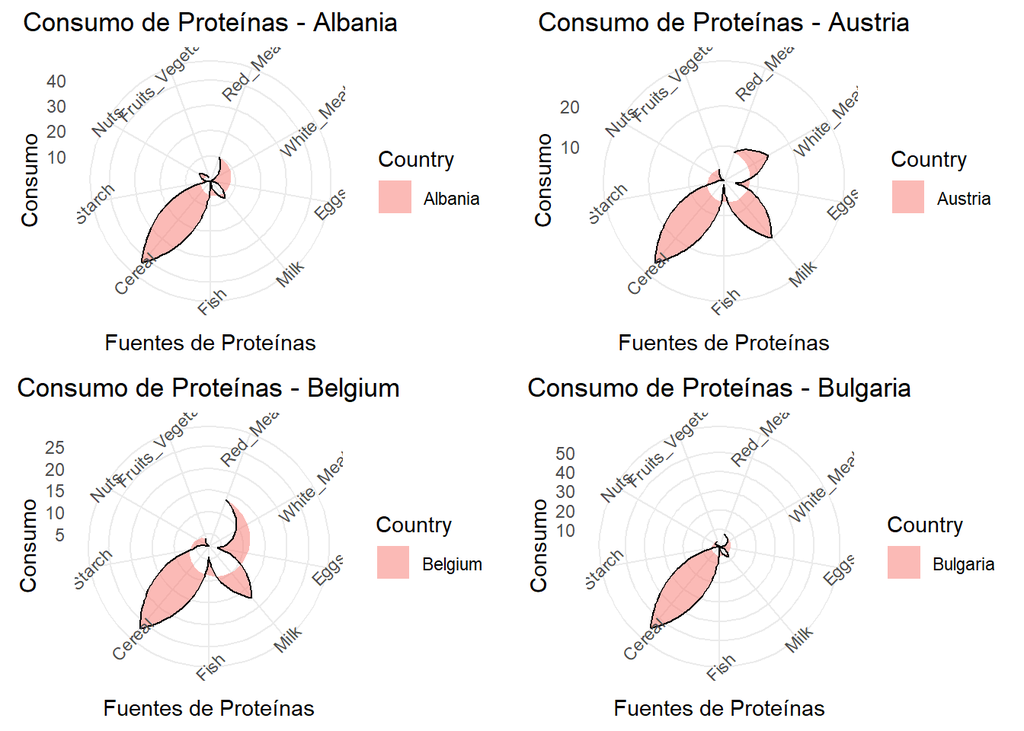

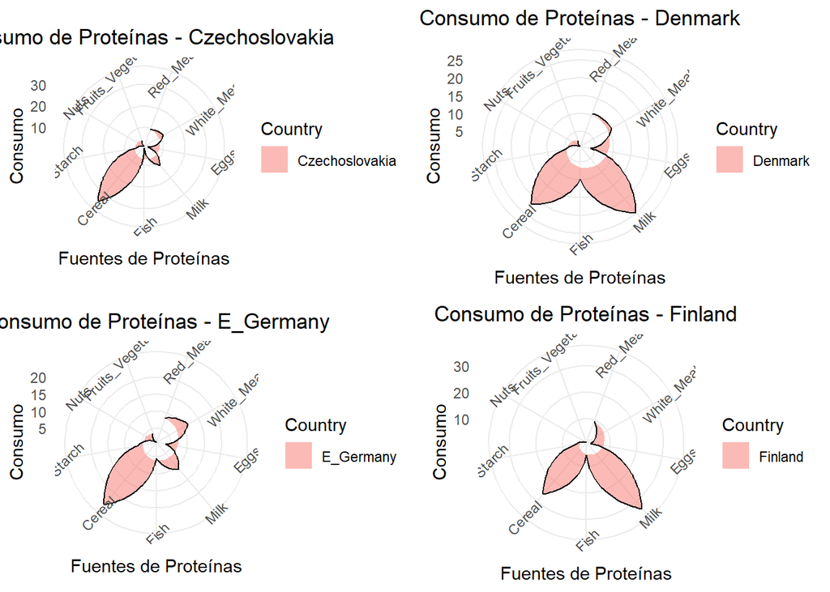

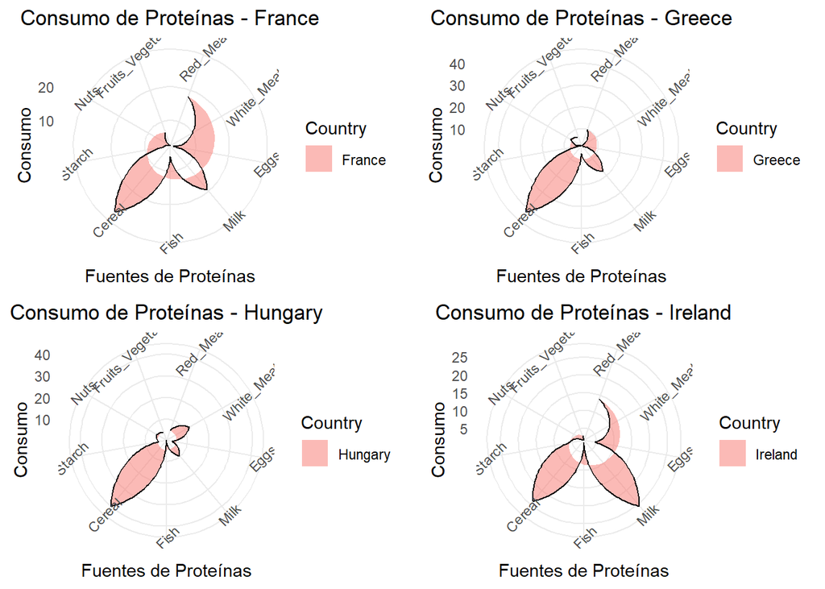

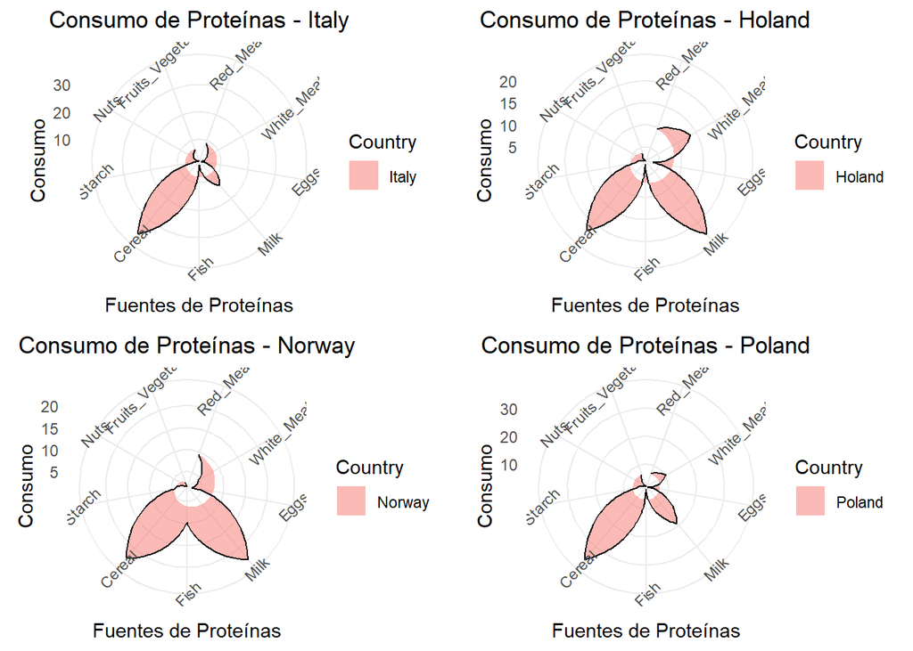

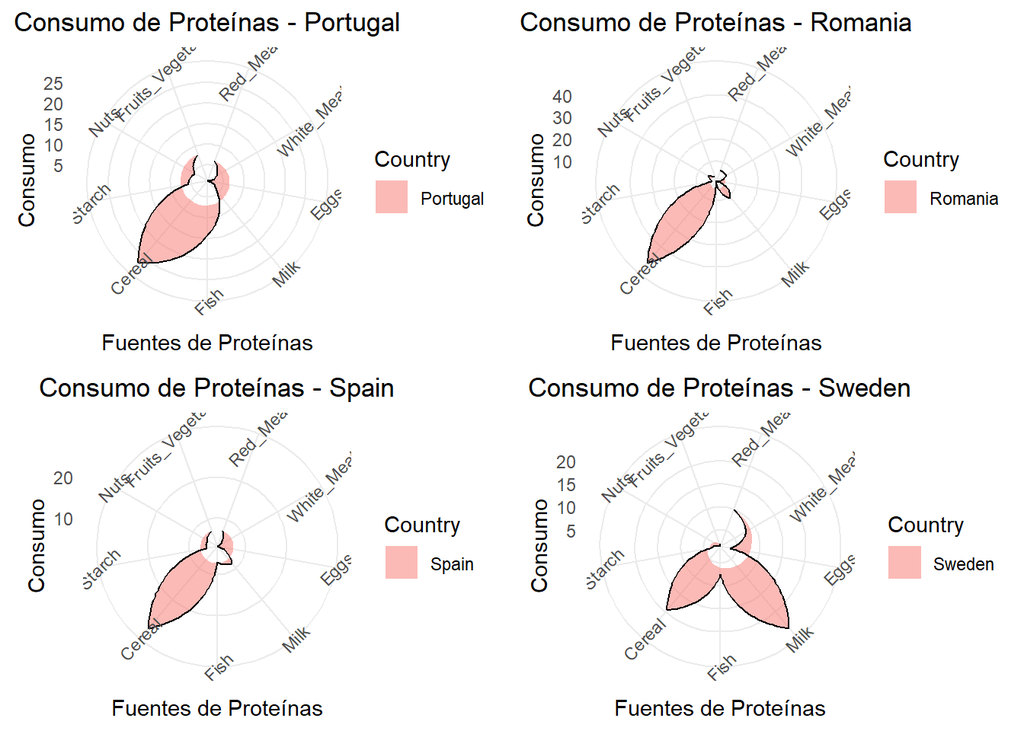

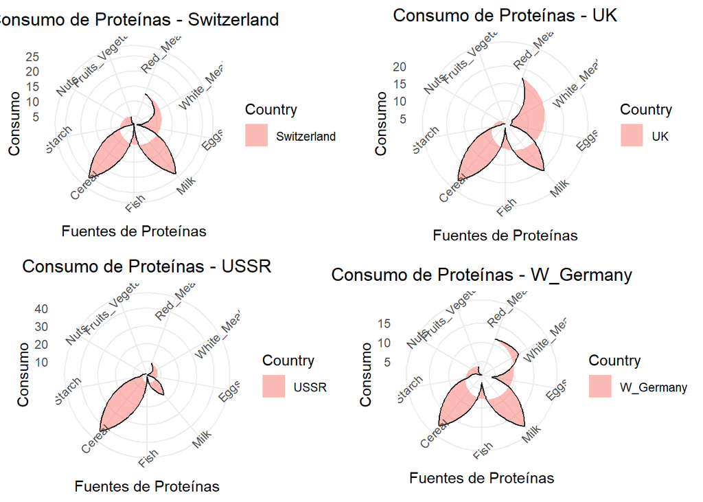

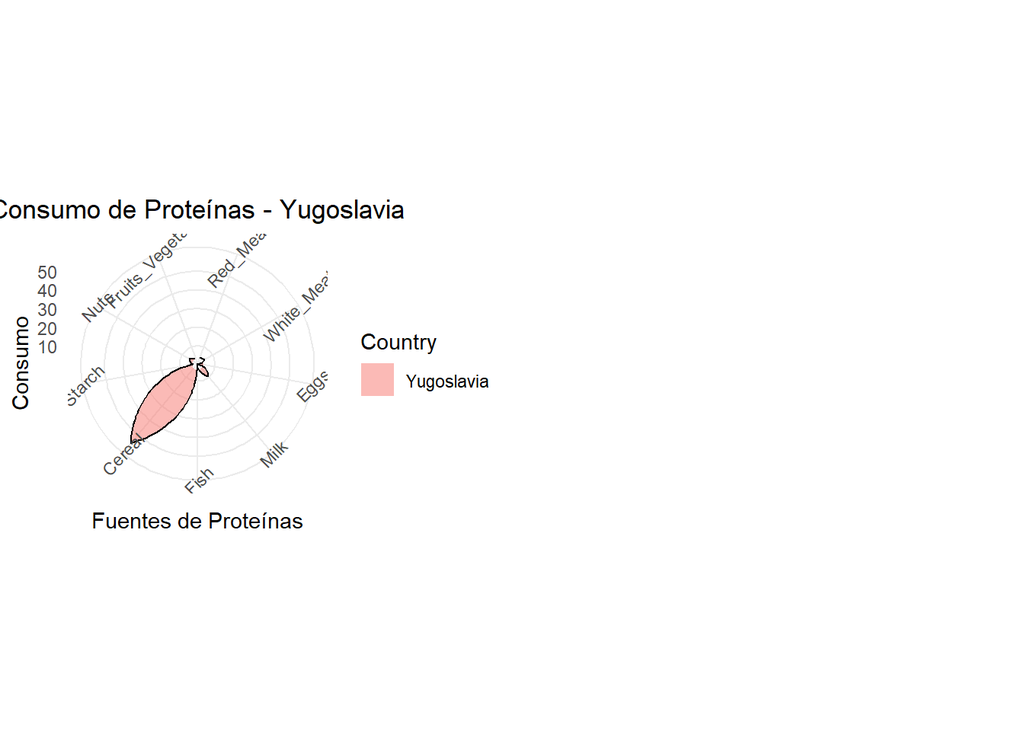

```r
library(ggplot2)
library(reshape2)
library(gridExtra)
```

A simple vista puedo sugerir agrupar los paises en 2 grupos. Los paises de Bulagria que solo consumen Ceral principalmente pueden agruparse con Albania por ejemplo. Paises como Austria que presentatn consumo de Ceral, Leche y Carnes Blancas pueden formar un grupo con , Belgium, Denmark, Germany , entre otros.

```
##                Red_Meat White_Meat Eggs Milk Fish Cereal Starch Nuts
## Albania            10.1        1.4  0.5  8.9  0.2   42.3    0.6  5.5
## Austria             8.9       14.0  4.3 19.9  2.1   28.0    3.6  1.3
## Belgium            13.5        9.3  4.1 17.5  4.5   26.6    5.7  2.1
## Bulgaria            7.8        6.0  1.6  8.3  1.2   56.7    1.1  3.7
## Czechoslovakia      9.7       11.4  2.8 12.5  2.0   34.3    5.0  1.1
## Denmark            10.6       10.8  3.7 25.0  9.9   21.9    4.8  0.7
##                Fruits_Vegetables
## Albania                      1.7
## Austria                      4.3
## Belgium                      4.0
## Bulgaria                     4.2
## Czechoslovakia               4.0
## Denmark                      2.4
```

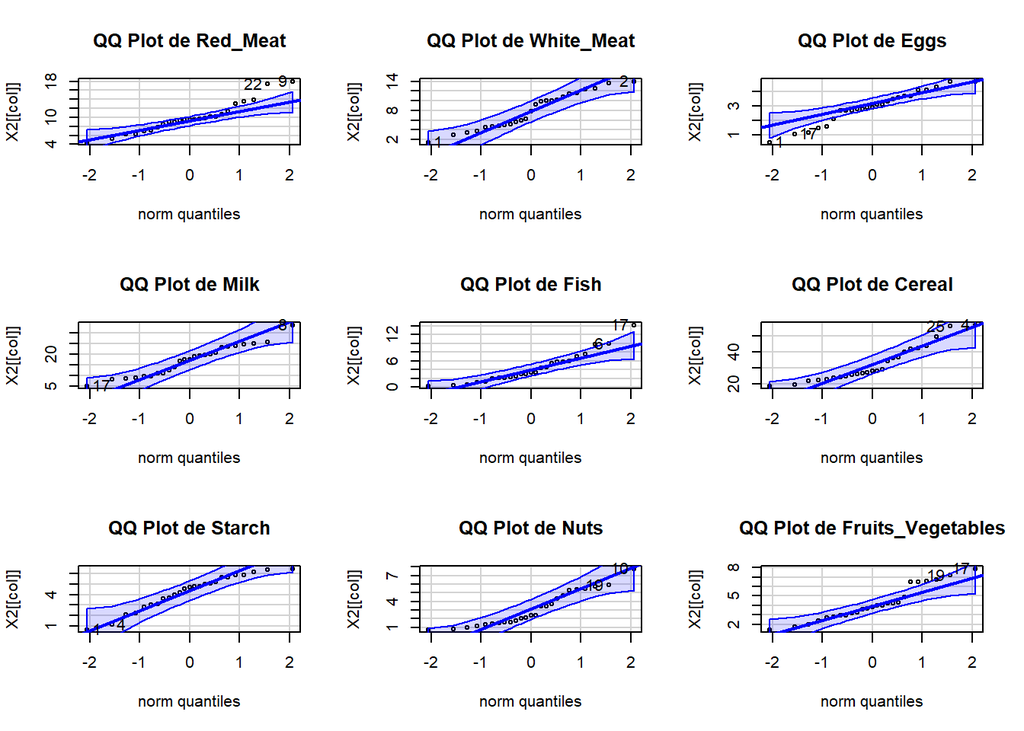

A simple vista podemos ver sierta discrepancia entre los puntos y la linea recta de color azul. Sin embargo puede que exista normalidad en la mayoría de las variables. e.

Se plantea las siguientes hipótesis para evaluar la normalidad multivariada de los datos:

- **H0**: Los datos provienen de una población Normal Multivariada.
- **H1**: Los datos NO provienen de una población Normal Multivariada.

```r
library(MVN)
mardia_result <- mvn(X2, mvnTest = "mardia")
mardia_result
```

```
## $multivariateNormality
##              Test          Statistic           p value Result
## 1 Mardia Skewness   168.086605971262  0.41858425807236    YES
## 2 Mardia Kurtosis -0.523571666842164 0.600576492382074    YES
## 3             MVN               <NA>              <NA>    YES
##
## $univariateNormality
##               Test          Variable Statistic   p value Normality
## 1 Anderson-Darling     Red_Meat         0.6627    0.0737    YES
## 2 Anderson-Darling    White_Meat        0.6238    0.0926    YES
## 3 Anderson-Darling       Eggs           0.3929    0.3508    YES
## 4 Anderson-Darling       Milk           0.3966    0.3435    YES
## 5 Anderson-Darling       Fish           0.7257    0.0509    YES
## 6 Anderson-Darling      Cereal          1.0013    0.0101    NO
## 7 Anderson-Darling      Starch          0.4254    0.2921    YES
## 8 Anderson-Darling       Nuts           0.9281    0.0155    NO
## 9 Anderson-Darling Fruits_Vegetables    0.7753    0.0380    NO
##
## $Descriptives
##                    n   Mean   Std.Dev Median  Min  Max 25th 75th        Skew
## Red_Meat          25  9.828  3.347078    9.5  4.4 18.0  7.8 10.6  0.77847879
## White_Meat        25  7.896  3.694081    7.8  1.4 14.0  4.9 10.8  0.03504453
## Eggs              25  2.936  1.117617    2.9  0.5  4.7  2.7  3.7 -0.39426844
## Milk              25 17.112  7.105416   17.6  4.9 33.7 11.1 23.3  0.21508664
## Fish              25  4.284  3.402533    3.4  0.2 14.2  2.1  5.8  1.09632534
## Cereal            25 32.248 10.974786   28.0 18.6 56.7 24.3 40.1  0.81881605
## Starch            25  4.276  1.634085    4.7  0.6  6.5  3.1  5.7 -0.58880387
## Nuts              25  3.072  1.985682    2.4  0.7  7.8  1.5  4.7  0.63338857
## Fruits_Vegetables 25  4.136  1.803903    3.8  1.4  7.9  2.9  4.9  0.54556050
##                     Kurtosis
## Red_Meat           0.2225442
## White_Meat        -1.4190709
## Eggs              -0.6646212
## Milk              -0.7787642
## Fish               0.7974802
## Cereal            -0.4981383
## Starch            -0.6590063
## Nuts              -0.8391066
## Fruits_Vegetables -0.8604672
```

Dado que no se rechaza la hipótesis nula (H0), se concluye que los datos provienen de una población Normal Multivariada. Esto sugiere que las suposiciones de normalidad son válidas para los análisis posteriores.

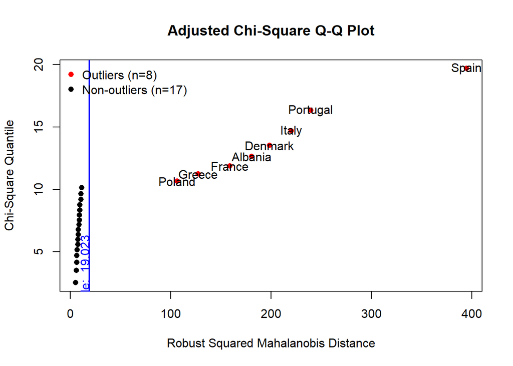

```
## $multivariateNormality
##              Test          Statistic           p value Result
## 1 Mardia Skewness   168.086605971262  0.41858425807236    YES
## 2 Mardia Kurtosis -0.523571666842164 0.600576492382074    YES
## 3             MVN               <NA>              <NA>    YES
##
## $univariateNormality
##               Test          Variable Statistic   p value Normality
## 1 Anderson-Darling     Red_Meat         0.6627    0.0737    YES
## 2 Anderson-Darling    White_Meat        0.6238    0.0926    YES
## 3 Anderson-Darling       Eggs           0.3929    0.3508    YES
## 4 Anderson-Darling       Milk           0.3966    0.3435    YES
## 5 Anderson-Darling       Fish           0.7257    0.0509    YES
## 6 Anderson-Darling      Cereal          1.0013    0.0101    NO
## 7 Anderson-Darling      Starch          0.4254    0.2921    YES
## 8 Anderson-Darling       Nuts           0.9281    0.0155    NO
## 9 Anderson-Darling Fruits_Vegetables    0.7753    0.0380    NO
##
## $Descriptives
##                    n   Mean   Std.Dev Median  Min  Max 25th 75th        Skew
## Red_Meat          25  9.828  3.347078    9.5  4.4 18.0  7.8 10.6  0.77847879
## White_Meat        25  7.896  3.694081    7.8  1.4 14.0  4.9 10.8  0.03504453
## Eggs              25  2.936  1.117617    2.9  0.5  4.7  2.7  3.7 -0.39426844
## Milk              25 17.112  7.105416   17.6  4.9 33.7 11.1 23.3  0.21508664
## Fish              25  4.284  3.402533    3.4  0.2 14.2  2.1  5.8  1.09632534
## Cereal            25 32.248 10.974786   28.0 18.6 56.7 24.3 40.1  0.81881605
## Starch            25  4.276  1.634085    4.7  0.6  6.5  3.1  5.7 -0.58880387
## Nuts              25  3.072  1.985682    2.4  0.7  7.8  1.5  4.7  0.63338857
## Fruits_Vegetables 25  4.136  1.803903    3.8  1.4  7.9  2.9  4.9  0.54556050
##                     Kurtosis
## Red_Meat           0.2225442
## White_Meat        -1.4190709
## Eggs              -0.6646212
## Milk              -0.7787642
## Fish               0.7974802
## Cereal            -0.4981383
## Starch            -0.6590063
## Nuts              -0.8391066
## Fruits_Vegetables -0.8604672
```

8 valores atípicos son encontrados con la prueba gráfico siendo el más alejado de todos ‘España’.

```r
 mu0 <- c(9, 7, 2, 15, 5, 30, 4, 3, 4)
Xbarra <- colMeans(X2)
S <- apply(X2, 2, sd)

n <- nrow(X2)
n
```

```
## [1] 25
```

```r
p <- ncol(X2)
p
```

```
## [1] 9
```

- Univariada:

```r
 p_values <- sapply(1:p, function(i) {
  t_test <- (Xbarra[i] - mu0[i]) / (S[i] / sqrt(n))
  p_value <- 2 * (1 - pt(abs(t_test), df = n - 1))
  return(p_value)
})
p_values
```

```
##          Red_Meat        White_Meat              Eggs              Milk
##      0.2280913981      0.2370278242      0.0003277511      0.1502482214
##              Fish            Cereal            Starch              Nuts
##      0.3032062741      0.3159698559      0.4067247572      0.8576561693
## Fruits_Vegetables
##      0.7095156149
```

Se observa que solo la variable **Eggs** tiene un p-valor menor a 0.05, lo que indica que se rechaza la hipótesis nula para esta variable, sugiriendo que su media es significativamente diferente de la población de referencia. Las demás variables no presentan diferencias significativas.

- Multivariada:

```r
 # --- PH multivariadas --- #
T2<-function(mu0,alpha,n,p){
Xbarra<-colMeans(X2)
S<-cov(X2)
InvS<-solve(S)
DifMed<-Xbarra - mu0
T2<-n%*%t(DifMed)%*%InvS%*%DifMed
return(T2)
}
```

```r
 T2_value <- T2(mu0, alpha = 0.05, n = n, p = p)
T2_value
```

```
##          [,1]
## [1,] 64.84185
```

```r
# Comparar con la distribución F
F_value <- (T2_value * (n - p)) / (p * (n - 1))
F_value
```

```
##        [,1]
## [1,] 4.8031
```

```r
p_value_multivariado <- 1 - pf(F_value, df1 = p, df2 = n - p)
p_value_multivariado
```

```
##            [,1]
## [1,] 0.00318293
```